# Decision Trees for Spam Detection

Malte Schierholz

5 Feb 2018

## Setup

```r
# library("ggplot2")
library("rpart")
library("partykit")
library("verification")
set.seed(353)
```

## Data

“Email spam data. 4601 email messages sent to”George" at HP-Labs.

He labeled 1813 of these as spam, with the remainder being good email (ham). The goal is to build a customized spam filter for George.

The feature set tracks 57 of the most commonly used, non-trivial words in the corpus, using a bag-of-words model. Recorded for each email message is the relative frequency [%] of each of these words and tokens. Included as well are three different recordings of capitalized letters.

These are a publicly available database, available from the UC Irvine data repository: archive.ics.uci.edu/ml/datasets/Spambase More details about the data can be found there.

Our data matrix has 59 columns:

- *spam* Logical variable, TRUE is spam, FALSE is ham (good email).
- *testid* Logical variable. An optional split into train (FALSE) and test (TRUE) data (as used in, for example “Elements of Statistical Learning”).
- The remainder of the columns are features used to build a prediction model."

(Data description copied from https://web.stanford.edu/~hastie/CASI/data.html)

```r
spam <- read.csv("SPAM.csv")
names(spam)[51:56] <- c("ch;","ch(","ch[","ch!","ch$","ch#")
spam$spam <- as.factor(as.numeric(spam$spam))
head(spam)
```

```
##   spam testid make address  all X3d  our over remove internet order mail
## 1    1   TRUE 0.00    0.64 0.64   0 0.32 0.00   0.00     0.00  0.00 0.00
## 2    1  FALSE 0.21    0.28 0.50   0 0.14 0.28   0.21     0.07  0.00 0.94
## 3    1   TRUE 0.06    0.00 0.71   0 1.23 0.19   0.19     0.12  0.64 0.25
## 4    1  FALSE 0.00    0.00 0.00   0 0.63 0.00   0.31     0.63  0.31 0.63
## 5    1  FALSE 0.00    0.00 0.00   0 0.63 0.00   0.31     0.63  0.31 0.63
## 6    1  FALSE 0.00    0.00 0.00   0 1.85 0.00   0.00     1.85  0.00 0.00
##   receive will people report addresses free business email  you credit
## 1    0.00 0.64   0.00   0.00      0.00 0.32     0.00  1.29 1.93   0.00
## 2    0.21 0.79   0.65   0.21      0.14 0.14     0.07  0.28 3.47   0.00
## 3    0.38 0.45   0.12   0.00      1.75 0.06     0.06  1.03 1.36   0.32
## 4    0.31 0.31   0.31   0.00      0.00 0.31     0.00  0.00 3.18   0.00
## 5    0.31 0.31   0.31   0.00      0.00 0.31     0.00  0.00 3.18   0.00
## 6    0.00 0.00   0.00   0.00      0.00 0.00     0.00  0.00 0.00   0.00
##   your font X000 money hp hpl george X650 lab labs telnet X857 data X415
```

[output cut: 27 more lines]

Split into training and test data and remove the splitting variable testid

```r
spam_train <- spam[spam$testid == FALSE, -2]
spam_test <- spam[spam$testid == TRUE, -2]
```

## Grow tree

The task is to predict if an email is spam based on all other variables (~ .).

- Build “class”ification tree with default parameters
- Bring it into the “party”-format to plot it

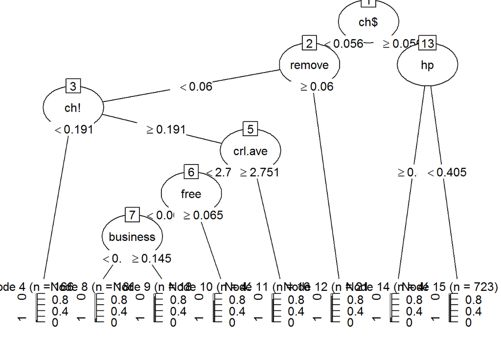

```r
rp <- rpart(spam ~ ., data = spam_train, method = "class")
party_rp <- as.party(rp)
plot(party_rp)
```

Build a small tree

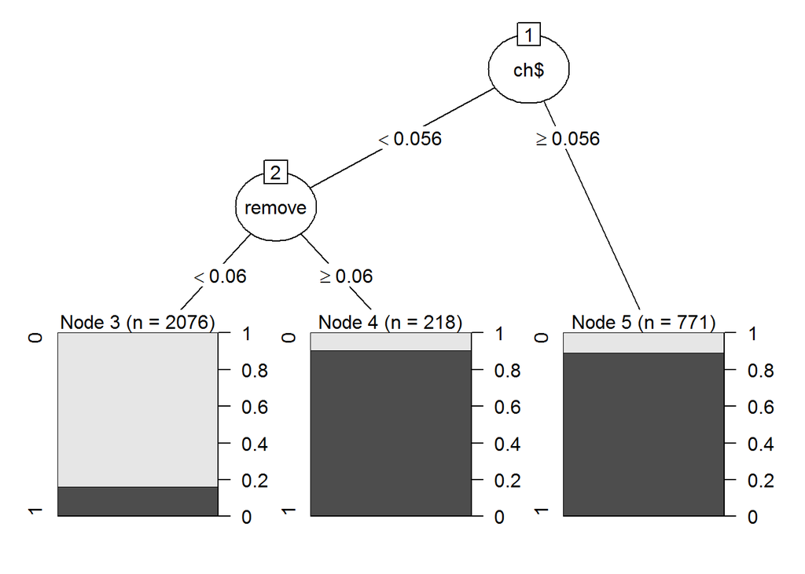

```r
rp <- rpart(spam ~ ., data = spam_train, model = TRUE, method = "class",
            control = rpart.control(minsplit = 100, # minimal number of observations in a node to try splitting
                                    minbucket = 100, # minimal number of observations in any terminal leaf node
                                    cp = 0.01, # minimal improvement trough splitting
                                    maxdepth = 3 # maximum tree depth (root node has depth 0)
                                    ))
party_rp <- as.party(rp)
plot(party_rp)
```

## Find optimal predictive tree with cost-complexity pruning

Build a very large tree

[figure not shown]

```r
rp <- rpart(spam ~ ., data = spam_train, model = TRUE, method = "class",
            control = rpart.control(minsplit = 10, # minimal number of observations in a node to try splitting
                                    minbucket = 3, # minimal number of observations in any terminal leaf node
                                    cp = 0.001, # minimal improvement trough splitting
                                    maxdepth = 30 # maximum tree depth (root node has depth 0)
                                    ))
party_rp <- as.party(rp)
plot(party_rp)
```

This tree overfits the data. Training error (rel error) decreases as the tree grows larger, but this does not generalize to new data for large trees. Cross-validated test error (xerror) remains rather constant for all trees with more than 10 splits.

```r
printcp(rp)
```

```
##
## Classification tree:
## rpart(formula = spam ~ ., data = spam_train, method = "class",
##     model = TRUE, control = rpart.control(minsplit = 10, minbucket = 3,
##         cp = 0.001, maxdepth = 30))
##
## Variables actually used in tree construction:
##  [1] business ch!      ch$      ch(      crl.ave  crl.long crl.tot
##  [8] edu      email    free     george   hp       internet money
## [15] order    our      over     pm       re       remove   will
## [22] X85      you      your
##
## Root node error: 1218/3065 = 0.39739
##
## n= 3065
##
##           CP nsplit rel error  xerror     xstd
## 1  0.4934319      0   1.00000 1.00000 0.022243
## 2  0.1444992      1   0.50657 0.50657 0.018226
## 3  0.0418719      2   0.36207 0.36289 0.015968
## 4  0.0279146      4   0.27833 0.28818 0.014474
## 5  0.0172414      5   0.25041 0.26273 0.013899
## 6  0.0114943      6   0.23317 0.24877 0.013567
## 7  0.0082102      7   0.22167 0.23481 0.013221
## 8  0.0057471      8   0.21346 0.22578 0.012990
## 9  0.0049261     10   0.20197 0.21675 0.012753
## 10 0.0041051     11   0.19704 0.21757 0.012774
## 11 0.0036946     12   0.19294 0.21839 0.012796
## 12 0.0032841     14   0.18555 0.21757 0.012774
## 13 0.0024631     18   0.17241 0.21593 0.012731
## 14 0.0016420     30   0.14286 0.21100 0.012598
## 15 0.0013684     35   0.13465 0.21264 0.012642
## 16 0.0012315     43   0.12069 0.20772 0.012509
## 17 0.0010000     47   0.11412 0.20772 0.012509
```

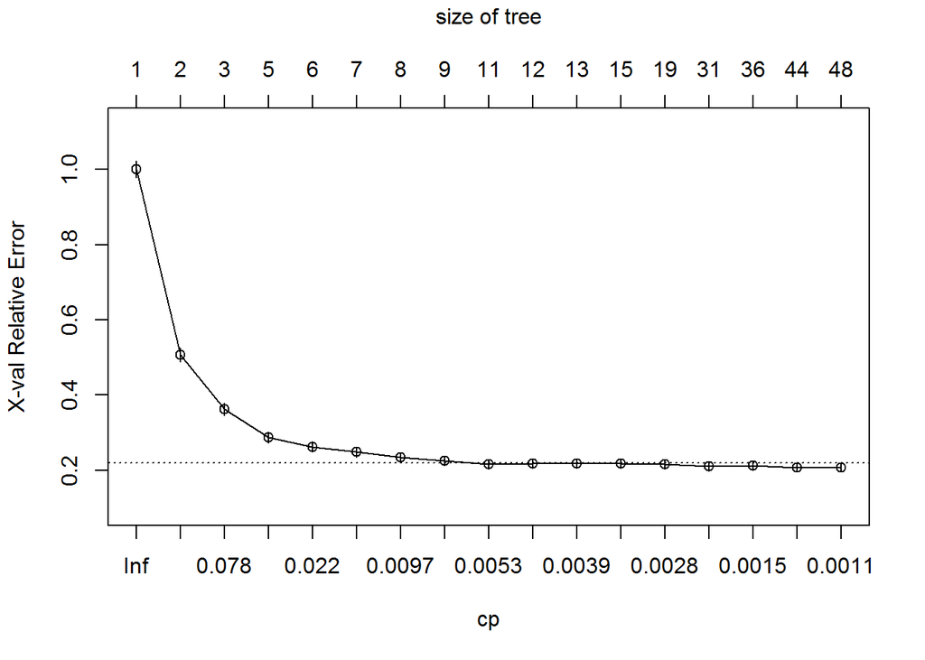

```r
plotcp(rp)
```

Another rule of thumb would be to choose the lowest level where the rel_error + xstd < xerror

```r
p_tree <- prune(rp, cp = 0.0049261)
party_p_tree <- as.party(p_tree)
party_p_tree
```

```
##
## Model formula:
## spam ~ make + address + all + X3d + our + over + remove + internet +
##     order + mail + receive + will + people + report + addresses +
##     free + business + email + you + credit + your + font + X000 +
##     money + hp + hpl + george + X650 + lab + labs + telnet +
##     X857 + data + X415 + X85 + technology + X1999 + parts + pm +
##     direct + cs + meeting + original + project + re + edu + table +
##     conference + `ch;` + `ch(` + `ch[` + `ch!` + `ch$` + `ch#` +
##     crl.ave + crl.long + crl.tot
##
## Fitted party:
## [1] root
## |   [2] ch$ < 0.0555
## |   |   [3] remove < 0.06
## |   |   |   [4] ch! < 0.191: 0 (n = 1663, err = 7.8%)
## |   |   |   [5] ch! >= 0.191
## |   |   |   |   [6] crl.ave < 2.7505
## |   |   |   |   |   [7] free < 0.065
## |   |   |   |   |   |   [8] business < 0.145: 0 (n = 186, err = 12.9%)
## |   |   |   |   |   |   [9] business >= 0.145: 1 (n = 18, err = 11.1%)
## |   |   |   |   |   [10] free >= 0.065: 1 (n = 43, err = 25.6%)
## |   |   |   |   [11] crl.ave >= 2.7505
## |   |   |   |   |   [12] pm >= 0.205: 0 (n = 7, err = 0.0%)
## |   |   |   |   |   [13] pm < 0.205: 1 (n = 159, err = 15.7%)
## |   |   [14] remove >= 0.06
## |   |   |   [15] george >= 0.15: 0 (n = 10, err = 0.0%)
## |   |   |   [16] george < 0.15: 1 (n = 208, err = 5.3%)
## |   [17] ch$ >= 0.0555
## |   |   [18] hp >= 0.405
## |   |   |   [19] remove < 0.075: 0 (n = 42, err = 2.4%)
## |   |   |   [20] remove >= 0.075: 1 (n = 6, err = 0.0%)
## |   |   [21] hp < 0.405
## |   |   |   [22] edu >= 0.505: 0 (n = 7, err = 0.0%)
## |   |   |   [23] edu < 0.505: 1 (n = 716, err = 5.2%)
##
## Number of inner nodes:    11
## Number of terminal nodes: 12
```

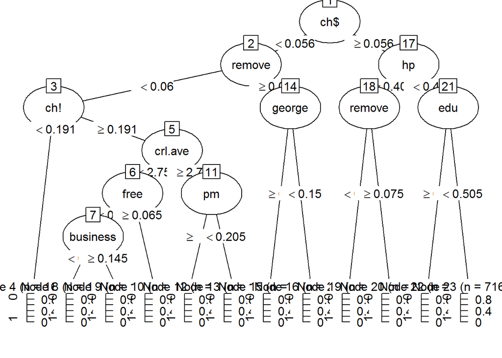

```r
plot(party_p_tree)
```

## Prediction

Use the pruned tree to predict if emails from the test set are spam or not.

```r
y_tree <- predict(party_p_tree, newdata = spam_test)
A <- verify(pred = y_tree, obs = spam_test$spam, frcst.type = "binary", obs.type = "binary" )
summary(A)
```

```
##
## The forecasts are binary, the observations are binary.
## The contingency table for the forecast
##
##       1   2
##   1 890  51
##   2  95 500
##
## PODy =      1
## Std. Err. for POD =  0.0001124
## TS   =      1
## Std. Err. for TS =  0.0001124
## ETS  =      0
## Std. Err. for ETS =  0
## FAR  =      0
## Std. Err. for FAR =  0
## HSS  =      0
## Std. Err. for HSS =  0
## PC   =      1
## Std. Err. for PC =  0.0001124
## BIAS =      1
## Odds Ratio =      0
## Log Odds Ratio =    NaN
## Std. Err. for log Odds Ratio =  17.32
## Odds Ratio Skill Score =     -1
## Std. Err. for Odds Ratio Skill Score =
## Extreme Dependency Score (EDS) =     -1
## Std. Err. for EDS =      0
## Symmetric Extreme Dependency Score (SEDS) =     -1
## Std. Err. for SEDS =     -0
## Extremal Dependence Index (EDI) =    NaN
## Std. Err. for EDI =    NaN
## Symmetric Extremal Dependence Index (SEDI) =    NaN
## Std. Err. for SEDI =    NaN
```

Maybe we like to predict probabilities that an email is spam?

```r
y_tree <- predict(party_p_tree, newdata = spam_test, type = "prob")[,2]
```

Here are a few measures that let us evaluate probabilistic predictions (as oposed to (0-1 predictions above).

```r
A <- verify(pred = y_tree, obs = as.numeric(as.character(spam_test$spam)), frcst.type = "prob", obs.type = "binary" )
```

```
## If baseline is not included, baseline values  will be calculated from the  sample obs.
```

```r
summary(A)
```

```
##
## The forecasts are probabilistic, the observations are binary.
## Sample baseline calculated from observations.
## Brier Score (BS)           =  0.08504
## Brier Score - Baseline     =  0.2373
## Skill Score                =  0.6417
## Reliability                =  0.0012
## Resolution                 =  0.1535
## Uncertainty              =  0.2373
```

There exist many performance measures to evaluate predictions. See also the R-package ROCR.

## Include missclassification costs and priors (only for binary outcomes)

The costs of misclassifiation are often not symmetric. On the one hand, if one deletes an email that *falsely* is predicted to be spam, one may miss an important email. High costs! On the other hand, it doesn’t matter much if some spam emails are not detected. A loss matrix defines such costs (defaults to 1 if misclassified).

Priors can be used to correct for non-representative training samples. It default to relative frequencies in the training data

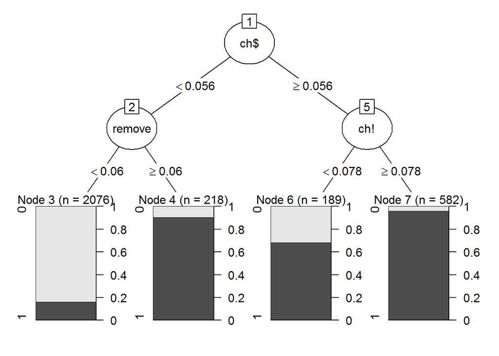

```r
rp <- rpart(spam ~ ., data = spam_train, model = TRUE, method = "class",
            parms = list(prior = c(0.5, 0.5), # invented numbers to say that both spam and ham are expected with probability 0.5 in new data (observed proportions: 0.6/0.4)
                         loss = matrix(c(0, 5, # costs for ham falsely classified as spam = 5
                                         1, 0), # costs for spam falsely classified as ham = 1
                                       byrow = TRUE, nrow = 2)
            ),
            control = rpart.control(minsplit = 100, # minimal number of observations in a node to try splitting
                                    minbucket = 100, # minimal number of observations in any terminal leaf node
                                    cp = 0.01, # minimal improvement trough splitting
                                    maxdepth = 3 # maximum tree depth (root node has depth 0)
                                    ))
party_rp <- as.party(rp)
plot(party_rp)
```

Although the majority of emails in Node 6 is spam, we may not want to classify all of it as spam. Costs are lower if our spam classifier labels them as ham.

Compare this to the small tree built earlier (identical parameters for rpart.control)

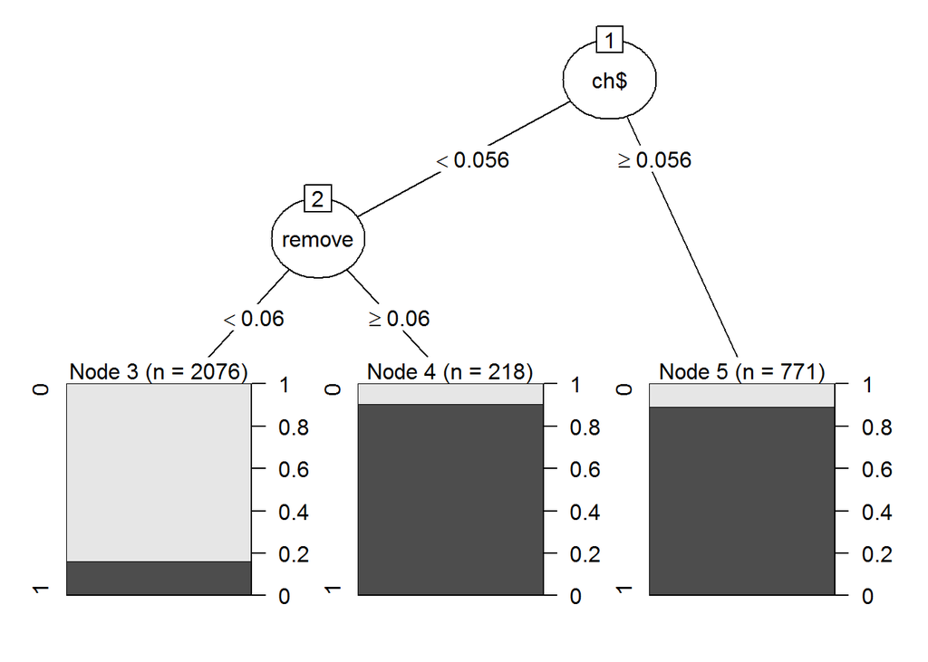

```r
rp <- rpart(spam ~ ., data = spam_train, model = TRUE, method = "class",
            control = rpart.control(minsplit = 100, # minimal number of observations in a node to try splitting
                                    minbucket = 100, # minimal number of observations in any terminal leaf node
                                    cp = 0.01, # minimal improvement trough splitting
                                    maxdepth = 3 # maximum tree depth (root node has depth 0)
                                    ))
party_rp <- as.party(rp)
plot(party_rp)
```

## Missing values

Decision Trees have their own methods to handle missing data. RPART allows for *surrogate variables*, hereby exploiting correlations between predictors. This means,

- Missing values are ignored when searching for the next best splitting point.
- Once a split is found, surrogate splits are created that ideally should have the same outcome as the original split.
- If the spliting variable from some node is missing, observations are passed to child nodes based on the surrogate variables.

Despite missingness, the observations can thus still be used in the tree building process.

## References

- Refer to https://cran.r-project.org/web/packages/rpart/vignettes/longintro.pdf for a complete description of rpart
- rpart is a standard tree implementation, but partykit is more flexible and variable selection is not biased. See https://cran.r-project.org/package=partykit (covered later)